# UEF 3622213 Regressiotekniikat, harj työ 2

## Elina Jeskanen, 256916

## 11.32. (a) Describe distributions.

```r
pcb = read.csv2("C:/Users/Elina/Dataa/pcb.csv", header = TRUE, sep = ";")
attach(pcb)
summary(pcb52)
```

```
##    Min. 1st Qu.  Median    Mean 3rd Qu.    Max.
##   0.020   0.228   0.477   0.958   0.892   9.060
```

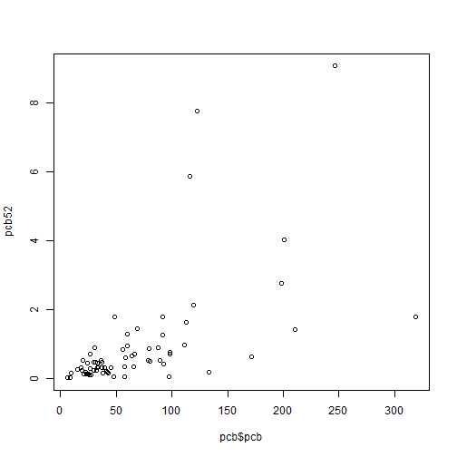

```r
plot(pcb$pcb, pcb52)
```

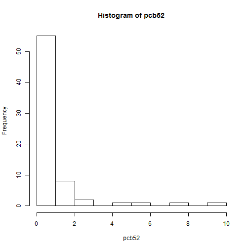

```r
hist(pcb52)
```

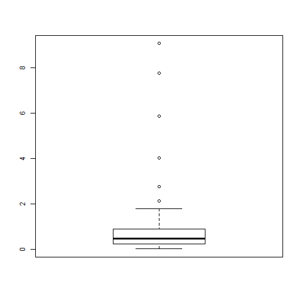

```r
boxplot(pcb52)
```

```r
summary(pcb118)
```

```
##    Min. 1st Qu.  Median    Mean 3rd Qu.    Max.
##   0.236   1.490   2.420   3.260   3.890  18.900
```

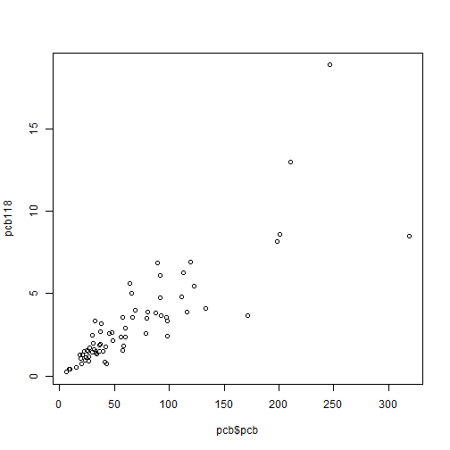

```r
plot(pcb$pcb, pcb118)
```

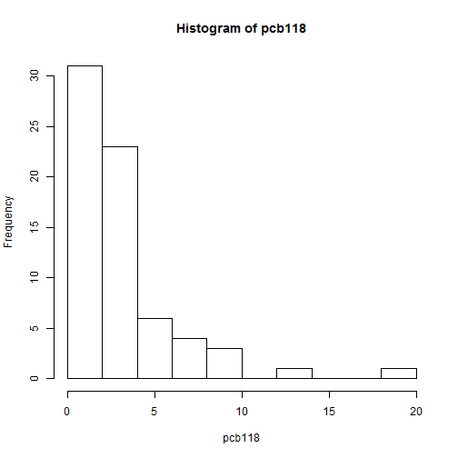

```r
hist(pcb118)
```

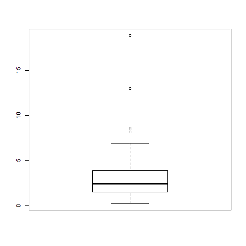

```r
boxplot(pcb118)
```

```r
summary(pcb138)
```

```
##    Min. 1st Qu.  Median    Mean 3rd Qu.    Max.
##    0.64    3.18    4.92    6.83    8.65   32.30
```

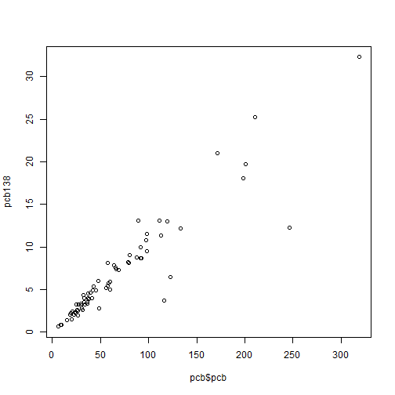

```r
plot(pcb$pcb, pcb138)
```

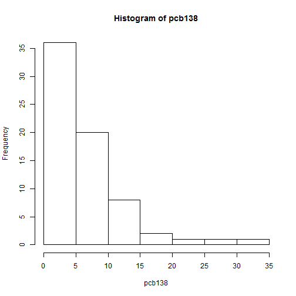

```r
hist(pcb138)
```

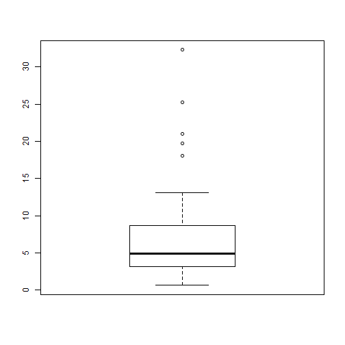

```r
boxplot(pcb138)
```

```r
summary(pcb180)
```

```
##    Min. 1st Qu.  Median    Mean 3rd Qu.    Max.
##   0.395   1.240   2.690   4.160   4.490  31.500
```

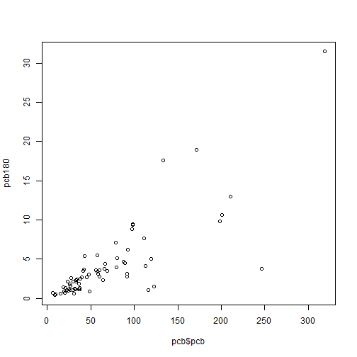

```r
plot(pcb$pcb, pcb180)
```

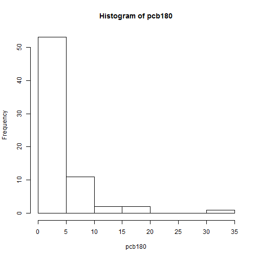

```r
hist(pcb180)
```

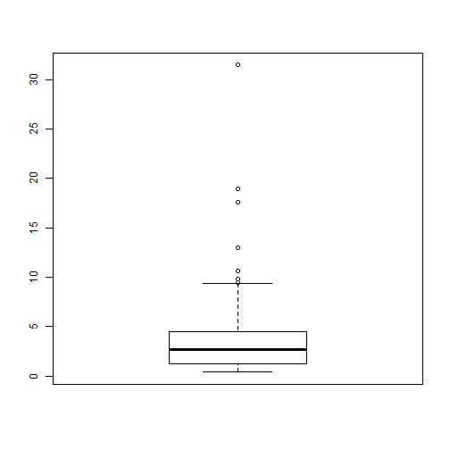

```r
boxplot(pcb180)
```

All the congeners of pcb would have quite uniform distributions, but due to a few observations having remarkably higher values the distributions end up being strongly right squed.

Most of the observations are scattered together, but then there seems to be 2 to 5 higher values for each variable, boxplot suggests that even 5 to 8 outliers per variable would be found.

This can also be seen in the summary statistics: the mean is significantly higher than the median, in one case even larger than the 3rd quartile and the maximum value for all these variables 5 to almost 10 times higher than the mean.

However the simple scatter plots show that the variables vary very similarly to each other when compared to pcb.

## 11.32. (b) Relationships between variables

```r
fourpcb = cbind(pcb52, pcb118, pcb138, pcb180)
cor(fourpcb)
```

```
##          pcb52 pcb118 pcb138  pcb180
## pcb52  1.00000 0.6849 0.3009 0.08693
## pcb118 0.68491 1.0000 0.7294 0.43744
## pcb138 0.30090 0.7294 1.0000 0.88230
## pcb180 0.08693 0.4374 0.8823 1.00000
```

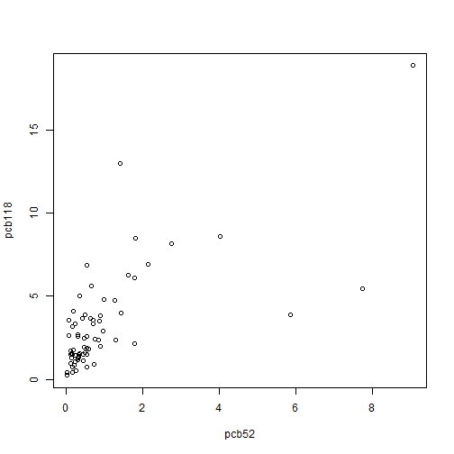

```r
plot(pcb52, pcb118)
```

```r
cor.test(pcb52, pcb118)
```

```
##
##  Pearson's product-moment correlation
##
## data:  pcb52 and pcb118
## t = 7.694, df = 67, p-value = 8.566e-11
## alternative hypothesis: true correlation is not equal to 0
## 95 percent confidence interval:
##  0.5349 0.7930
## sample estimates:
##    cor
## 0.6849
```

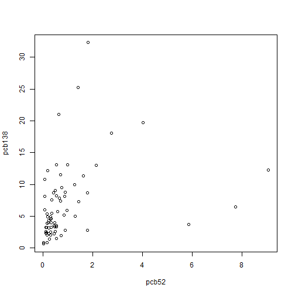

```r
plot(pcb52, pcb138)
```

```r
cor.test(pcb52, pcb138)
```

```
##
##  Pearson's product-moment correlation
##
## data:  pcb52 and pcb138
## t = 2.583, df = 67, p-value = 0.01199
## alternative hypothesis: true correlation is not equal to 0
## 95 percent confidence interval:
##  0.06914 0.50184
## sample estimates:
##    cor
## 0.3009
```

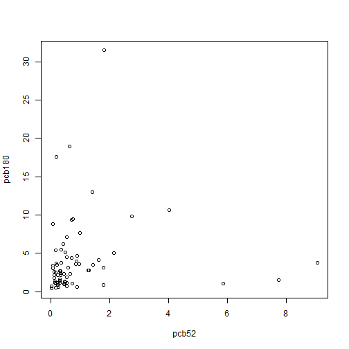

```r
plot(pcb52, pcb180)
```

```r
cor.test(pcb52, pcb180)
```

```
##
##  Pearson's product-moment correlation
##
## data:  pcb52 and pcb180
## t = 0.7143, df = 67, p-value = 0.4776
## alternative hypothesis: true correlation is not equal to 0
## 95 percent confidence interval:
##  -0.1529  0.3171
## sample estimates:
##     cor
## 0.08693
```

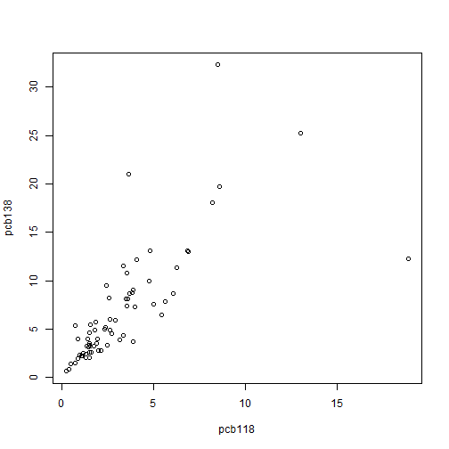

```r
plot(pcb118, pcb138)
```

```r
cor.test(pcb118, pcb138)
```

```
##
##  Pearson's product-moment correlation
##
## data:  pcb118 and pcb138
## t = 8.727, df = 67, p-value = 1.181e-12
## alternative hypothesis: true correlation is not equal to 0
## 95 percent confidence interval:
##  0.5955 0.8238
## sample estimates:
##    cor
## 0.7294
```

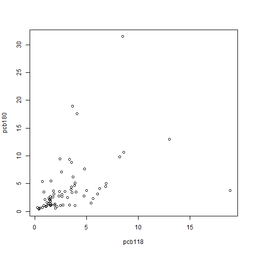

```r
plot(pcb118, pcb180)
```

```r
cor.test(pcb118, pcb180)
```

```
##
##  Pearson's product-moment correlation
##
## data:  pcb118 and pcb180
## t = 3.982, df = 67, p-value = 0.0001709
## alternative hypothesis: true correlation is not equal to 0
## 95 percent confidence interval:
##  0.2240 0.6109
## sample estimates:
##    cor
## 0.4374
```

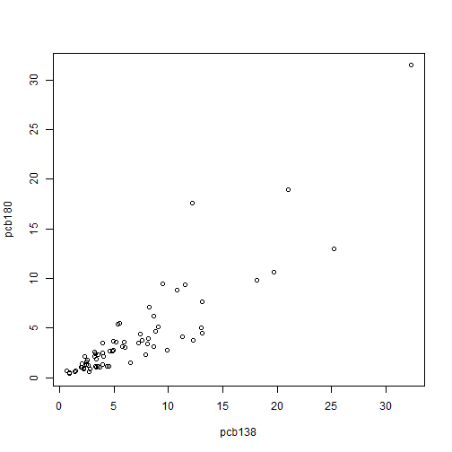

```r
plot(pcb138, pcb180)
```

```r
cor.test(pcb138, pcb180)  ## How could I get only the p-value and correlation out of this output?
```

```
##
##  Pearson's product-moment correlation
##
## data:  pcb138 and pcb180
## t = 15.34, df = 67, p-value < 2.2e-16
## alternative hypothesis: true correlation is not equal to 0
## 95 percent confidence interval:
##  0.8160 0.9257
## sample estimates:
##    cor
## 0.8823
```

All the four congeners of pcb are positively correlated to each other.Pcb138 and pcb180 have the highest correlation at 0.88. Pcb52 and pcb180 has the lowest correlation at 0.09 and the correlation is not significant (p-value=0.48). All the other variables are significantly correlated with each other.

It seems like the data is most correlated at lower values and the largest values, the “outliers” seem to be causing most of the uncorrelation.

## 11.33. (a) Predict pcb with Multipe regression. Write the model and include assumptions.

The model:

y_i=beta_0 + beta_1 * x_i1 + beta_2 * x_i2 + … + beta_k * x_ik + epsilon_i

Assumptions:

The error epsilon is an independent variable with a mean of zero and variance of sigma squared.

## 11.33. (b) RUn regression and summarize results.

```r
model = lm(pcb$pcb ~ fourpcb)
summary(model)
```

```
##
## Call:
## lm(formula = pcb$pcb ~ fourpcb)
##
## Residuals:
##     Min      1Q  Median      3Q     Max
## -22.086  -2.455   0.028   2.773  22.549
##
## Coefficients:
##               Estimate Std. Error t value Pr(>|t|)
## (Intercept)      0.937      1.229    0.76     0.45
## fourpcbpcb52    11.873      0.729   16.29  < 2e-16 ***
## fourpcbpcb118    3.761      0.642    5.85  1.8e-07 ***
## fourpcbpcb138    3.884      0.498    7.80  7.2e-11 ***
## fourpcbpcb180    4.182      0.432    9.69  3.6e-14 ***
## ---
## Signif. codes:  0 '***' 0.001 '**' 0.01 '*' 0.05 '.' 0.1 ' ' 1
##
## Residual standard error: 6.38 on 64 degrees of freedom
## Multiple R-squared:  0.989,  Adjusted R-squared:  0.988
## F-statistic: 1.46e+03 on 4 and 64 DF,  p-value: <2e-16
```

The model: pcb= 11.87*pcb52 + 3.76*pcb118 + 3.88*pcb138 + 4.18*pcb180

All the variables seem to be very significant. Only the intercept is not significant and it can be left out of the model. The R-squared is also very high, 0.9891, and so the model seems to be intrepreting very well pcb.

## 11.33. © Examine the residuals and their normality. Plot them against variables and look for patterns.

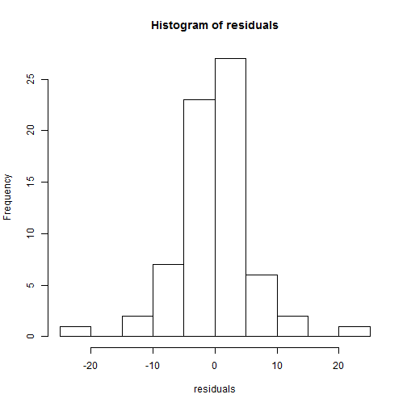

```r
pcb_predict = as.numeric(predict(model, data.frame(fourpcb)))
residuals = pcb$pcb - pcb_predict
hist(residuals)
```

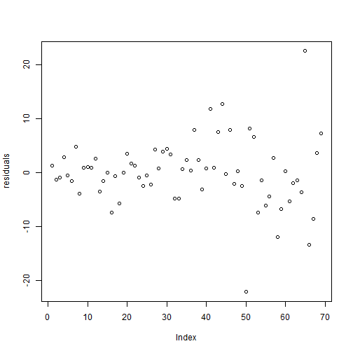

```r
plot(residuals)
```

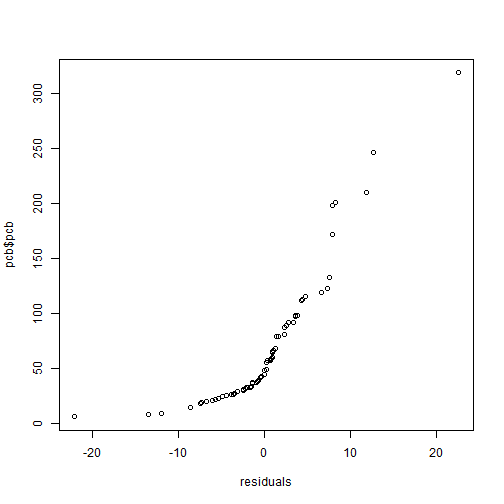

```r
qqplot(residuals, pcb$pcb)
```

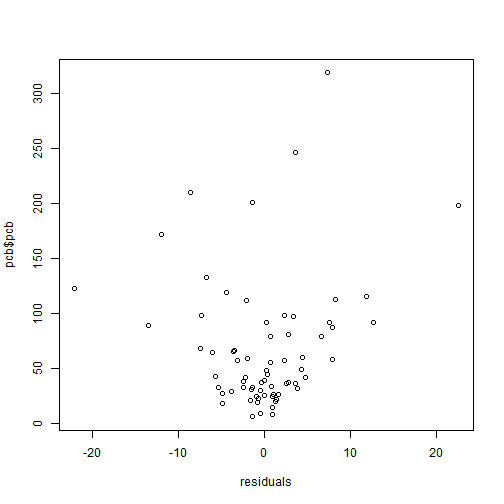

```r
plot(residuals, pcb$pcb)
```

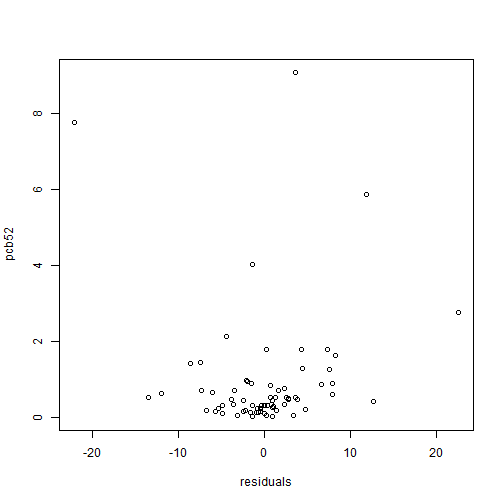

```r
plot(residuals, pcb52)
```

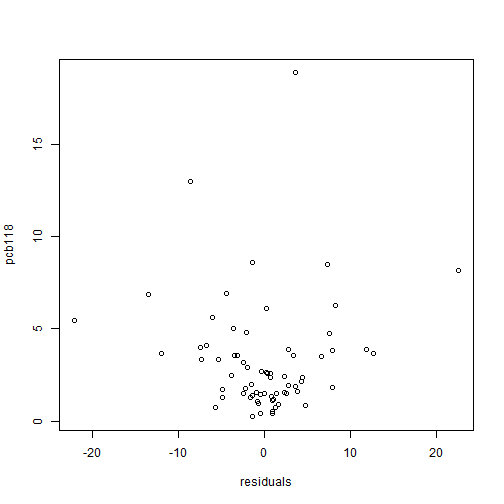

```r
plot(residuals, pcb118)
```

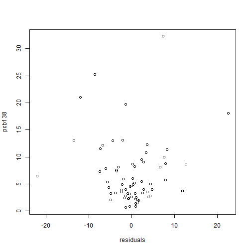

```r
plot(residuals, pcb138)
```

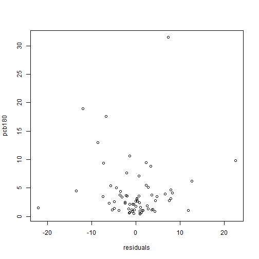

```r
plot(residuals, pcb180)
```

As expected, the residuals have bigger values when the amount of pcb is bigger. The residuals seem to be normal as seen in the histogram. However the scatterplot shows nonlinearity in variance and heteroskedastisity, since residuals seem to be the bigger the bigger the dependent and the explanatory variables are.

## 11.34. (a) Specimen numbers of over- and underestimating outliers.

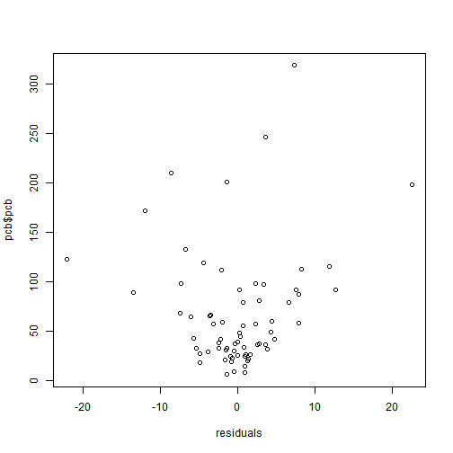

```r
plot(residuals, pcb$pcb)
```

```r
c(max(residuals), which(residuals == max(residuals), arr.ind = TRUE))
```

```
## [1] 22.55 65.00
```

```r
c(max(residuals), which(residuals == min(residuals), arr.ind = TRUE))
```

```
## [1] 22.55 50.00
```

The specimen for which the model is underestimating its value, is the specimen for which the residual is maximum and is specimen number 65.

The specimen for which the model is overestimating its value, is the specimen for which the residual is minimum and is specimen number 50.

## 11.34 (b) Rerun the analysis with the two suspected outliers omitted and compare results.

```r
pcb_oo = rbind(pcb[1:49, ], pcb[51:64, ], pcb[66:69, ])
fourpcb_oo = cbind(pcb_oo$pcb52, pcb_oo$pcb118, pcb_oo$pcb138, pcb_oo$pcb180)
model_oo = lm(pcb_oo$pcb ~ fourpcb_oo)
summary(model)
```

```
##
## Call:
## lm(formula = pcb$pcb ~ fourpcb)
##
## Residuals:
##     Min      1Q  Median      3Q     Max
## -22.086  -2.455   0.028   2.773  22.549
##
## Coefficients:
##               Estimate Std. Error t value Pr(>|t|)
## (Intercept)      0.937      1.229    0.76     0.45
## fourpcbpcb52    11.873      0.729   16.29  < 2e-16 ***
## fourpcbpcb118    3.761      0.642    5.85  1.8e-07 ***
## fourpcbpcb138    3.884      0.498    7.80  7.2e-11 ***
## fourpcbpcb180    4.182      0.432    9.69  3.6e-14 ***
## ---
## Signif. codes:  0 '***' 0.001 '**' 0.01 '*' 0.05 '.' 0.1 ' ' 1
##
## Residual standard error: 6.38 on 64 degrees of freedom
## Multiple R-squared:  0.989,  Adjusted R-squared:  0.988
## F-statistic: 1.46e+03 on 4 and 64 DF,  p-value: <2e-16
```

```r
summary(model_oo)
```

```
##
## Call:
## lm(formula = pcb_oo$pcb ~ fourpcb_oo)
##
## Residuals:
##     Min      1Q  Median      3Q     Max
## -12.242  -2.176  -0.138   1.704  14.205
##
## Coefficients:
##             Estimate Std. Error t value Pr(>|t|)
## (Intercept)    1.628      0.886    1.84    0.071 .
## fourpcb_oo1   14.442      0.696   20.75  < 2e-16 ***
## fourpcb_oo2    2.600      0.516    5.03  4.4e-06 ***
## fourpcb_oo3    4.054      0.375   10.80  6.9e-16 ***
## fourpcb_oo4    4.109      0.317   12.94  < 2e-16 ***
## ---
## Signif. codes:  0 '***' 0.001 '**' 0.01 '*' 0.05 '.' 0.1 ' ' 1
##
## Residual standard error: 4.56 on 62 degrees of freedom
## Multiple R-squared:  0.994,  Adjusted R-squared:  0.994
## F-statistic: 2.63e+03 on 4 and 62 DF,  p-value: <2e-16
```

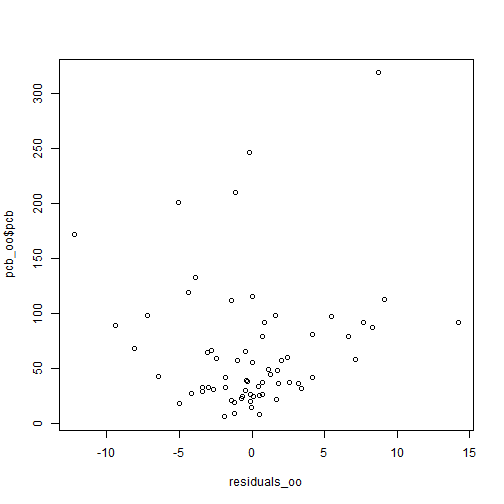

```r
pcb_predict_oo = as.numeric(predict(model_oo, data.frame(fourpcb_oo)))
residuals_oo = pcb_oo$pcb - pcb_predict_oo
plot(residuals_oo, pcb_oo$pcb)
```

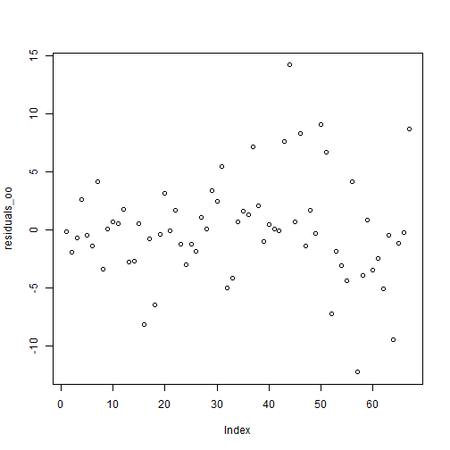

```r
plot(residuals_oo)  ## This has lost it's 'trumpet'' shape also. But what does the 'index' express here?
```

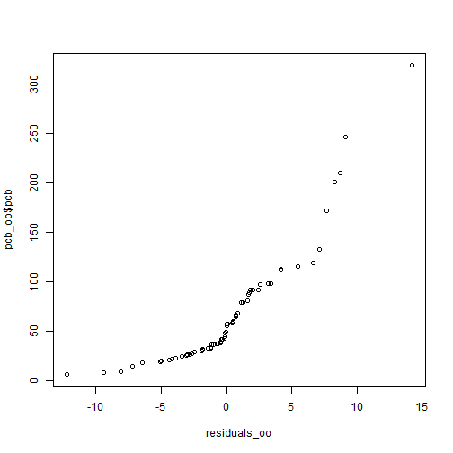

```r
qqplot(residuals_oo, pcb_oo$pcb)
```

By omitting the two outliers the residuals have nearly lost their heteroskedastisity!

But can we do so? What if they were real values and not outliers?

## Extra plots and calculations

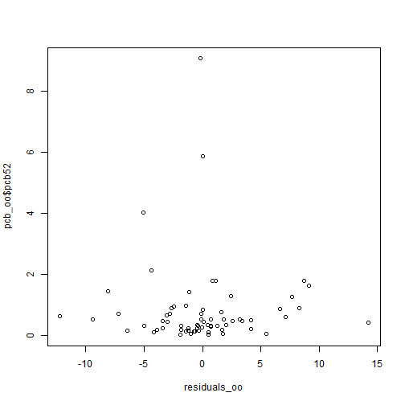

```r
plot(residuals_oo, pcb_oo$pcb52)
```

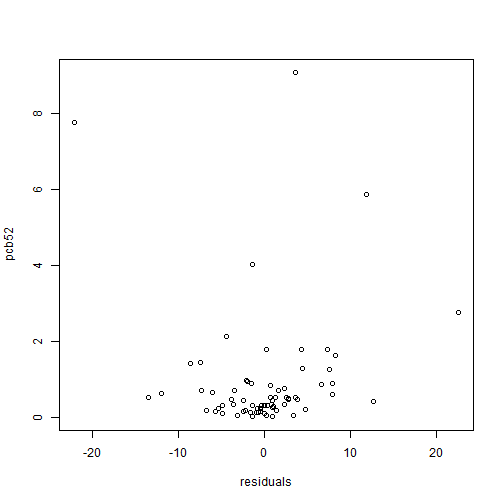

```r
plot(residuals, pcb52)
```

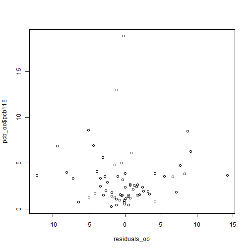

```r
plot(residuals_oo, pcb_oo$pcb118)
```

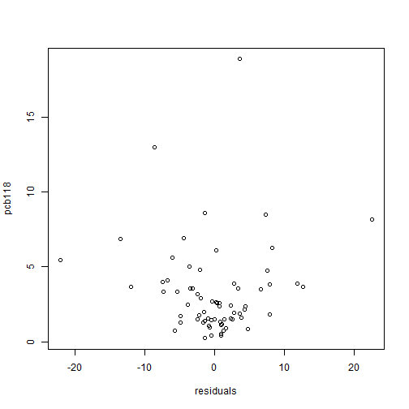

```r
plot(residuals, pcb118)
```

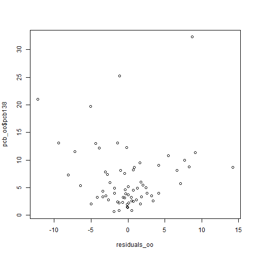

```r
plot(residuals_oo, pcb_oo$pcb138)
```

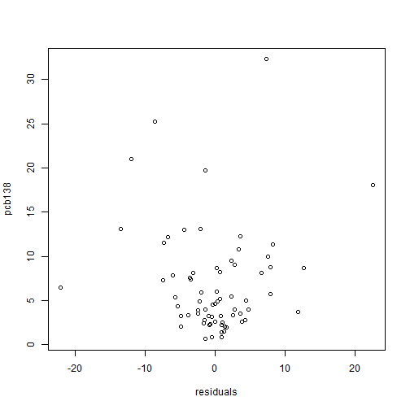

```r
plot(residuals, pcb138)
```

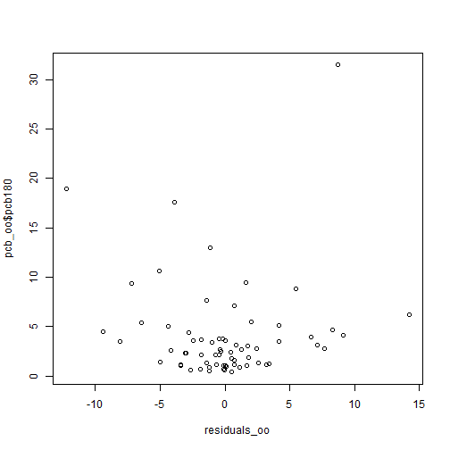

```r
plot(residuals_oo, pcb_oo$pcb180)
```

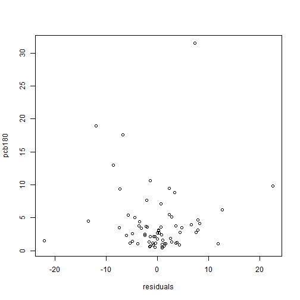

```r
plot(residuals, pcb180)
```

```r
cor(fourpcb)
```

```
##          pcb52 pcb118 pcb138  pcb180
## pcb52  1.00000 0.6849 0.3009 0.08693
## pcb118 0.68491 1.0000 0.7294 0.43744
## pcb138 0.30090 0.7294 1.0000 0.88230
## pcb180 0.08693 0.4374 0.8823 1.00000
```

```r
cor(fourpcb_oo)
```

```
##        [,1]   [,2]   [,3]   [,4]
## [1,] 1.0000 0.7420 0.3302 0.1214
## [2,] 0.7420 1.0000 0.7200 0.4309
## [3,] 0.3302 0.7200 1.0000 0.8842
## [4,] 0.1214 0.4309 0.8842 1.0000
```

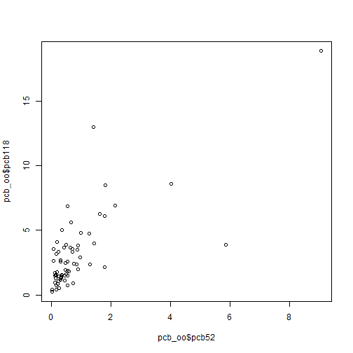

```r
plot(pcb_oo$pcb52, pcb_oo$pcb118)
```

```r
cor.test(pcb_oo$pcb52, pcb_oo$pcb118)
```

```
##
##  Pearson's product-moment correlation
##
## data:  pcb_oo$pcb52 and pcb_oo$pcb118
## t = 8.923, df = 65, p-value = 6.768e-13
## alternative hypothesis: true correlation is not equal to 0
## 95 percent confidence interval:
##  0.6106 0.8336
## sample estimates:
##   cor
## 0.742
```

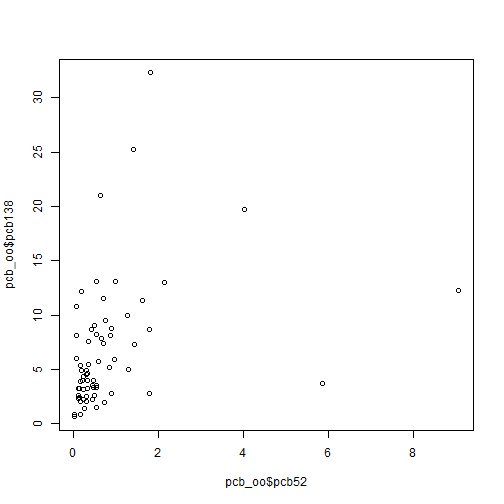

```r
plot(pcb_oo$pcb52, pcb_oo$pcb138)
```

```r
cor.test(pcb_oo$pcb52, pcb_oo$pcb138)
```

```
##
##  Pearson's product-moment correlation
##
## data:  pcb_oo$pcb52 and pcb_oo$pcb138
## t = 2.82, df = 65, p-value = 0.006355
## alternative hypothesis: true correlation is not equal to 0
## 95 percent confidence interval:
##  0.09774 0.52849
## sample estimates:
##    cor
## 0.3302
```

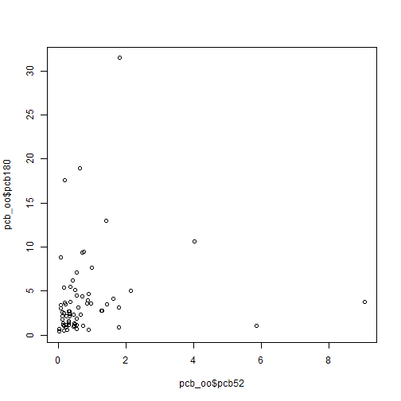

```r
plot(pcb_oo$pcb52, pcb_oo$pcb180)
```

```r
cor.test(pcb_oo$pcb52, pcb_oo$pcb180)
```

```
##
##  Pearson's product-moment correlation
##
## data:  pcb_oo$pcb52 and pcb_oo$pcb180
## t = 0.9858, df = 65, p-value = 0.3279
## alternative hypothesis: true correlation is not equal to 0
## 95 percent confidence interval:
##  -0.1224  0.3513
## sample estimates:
##    cor
## 0.1214
```

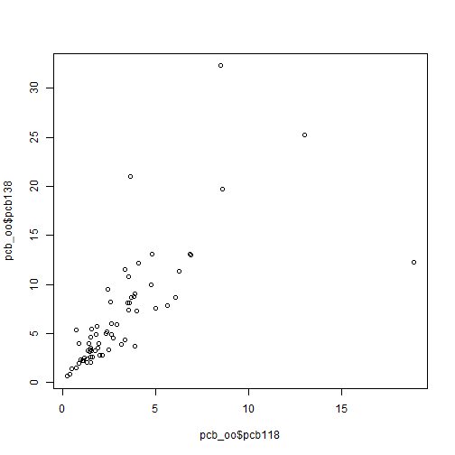

```r
plot(pcb_oo$pcb118, pcb_oo$pcb138)
```

```r
cor.test(pcb_oo$pcb118, pcb_oo$pcb138)
```

```
##
##  Pearson's product-moment correlation
##
## data:  pcb_oo$pcb118 and pcb_oo$pcb138
## t = 8.365, df = 65, p-value = 6.561e-12
## alternative hypothesis: true correlation is not equal to 0
## 95 percent confidence interval:
##  0.5802 0.8186
## sample estimates:
##  cor
## 0.72
```

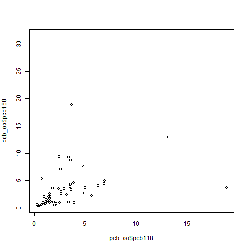

```r
plot(pcb_oo$pcb118, pcb_oo$pcb180)
```

```r
cor.test(pcb_oo$pcb118, pcb_oo$pcb180)
```

```
##
##  Pearson's product-moment correlation
##
## data:  pcb_oo$pcb118 and pcb_oo$pcb180
## t = 3.85, df = 65, p-value = 0.0002726
## alternative hypothesis: true correlation is not equal to 0
## 95 percent confidence interval:
##  0.2127 0.6082
## sample estimates:
##    cor
## 0.4309
```

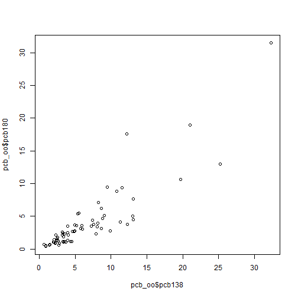

```r
plot(pcb_oo$pcb138, pcb_oo$pcb180)
```

```r
cor.test(pcb_oo$pcb138, pcb_oo$pcb180)
```

```
##
##  Pearson's product-moment correlation
##
## data:  pcb_oo$pcb138 and pcb_oo$pcb180
## t = 15.26, df = 65, p-value < 2.2e-16
## alternative hypothesis: true correlation is not equal to 0
## 95 percent confidence interval:
##  0.8177 0.9274
## sample estimates:
##    cor
## 0.8842
```

```r
detach(pcb)
```